# midterm

Korede Olugbenle

## Midterm.

#### 1. Summarize the planes

1a) For each plane (i.e. tailnum), compute its average delay, the average distance of a flight, and the number of total times that it appears in the flights data. Print the first few lines of this data.

1b) Join this to the plane data set.

1c) Then, make three plots. In all plots, put the average delay on the vertical axis. On the horizontal axis, plot (1) average distance, then (2) total number of times that it appears in the flights data, then in the last plot (3) the year the plane was built.

```r
# put your answer here.

avgs <- flights %>% group_by(tailnum) %>%
  summarize(mean_delay = mean(arr_delay, na.rm = T), mean_dist = mean(distance, na.rm = T)) %>%
  filter(complete.cases(mean_delay, mean_dist)) %>% mutate(sum = complete.cases(mean_delay, mean_dist))

head(avgs)
```

```
## # A tibble: 6 x 4
##   tailnum mean_delay mean_dist sum
##   <chr>        <dbl>     <dbl> <lgl>
## 1 D942DN       31.5       854. TRUE
## 2 N0EGMQ        9.98      676. TRUE
## 3 N10156       12.7       758. TRUE
## 4 N102UW        2.94      536. TRUE
## 5 N103US       -6.93      535. TRUE
## 6 N104UW        1.80      535. TRUE
```

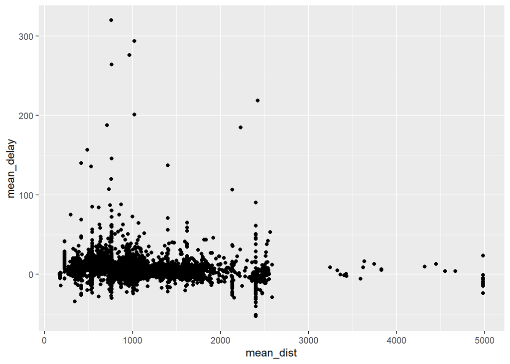

```r
joint <- planes %>%
  left_join(avgs, by = "tailnum")

joint %>% ggplot(aes(mean_dist, mean_delay)) + geom_point()
```

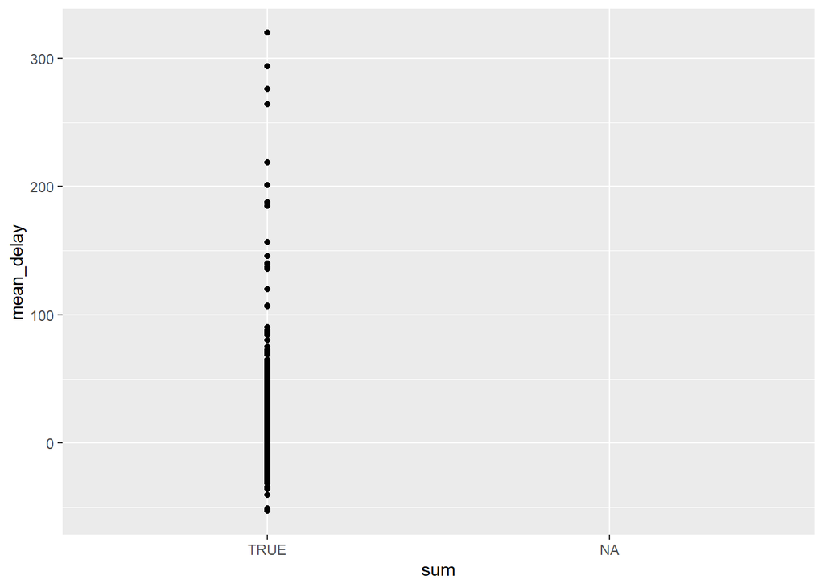

```r
joint %>% ggplot(aes(sum, mean_delay)) + geom_point()
```

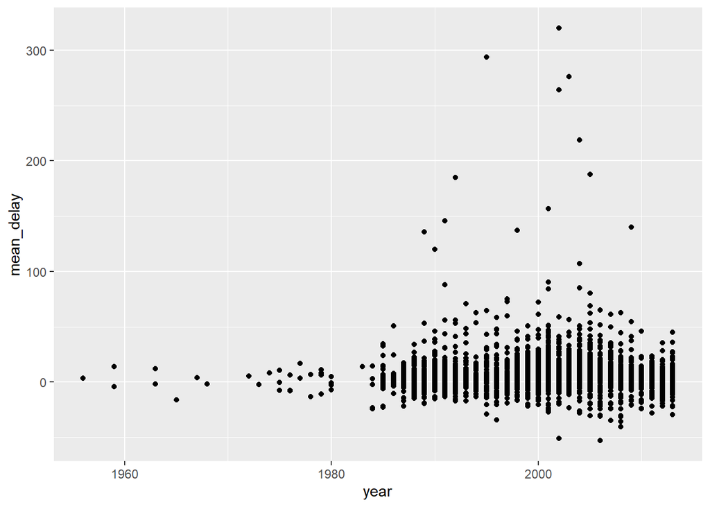

```r
joint %>% ggplot(aes(year, mean_delay)) + geom_point()
```

#### 2. Distance vs flight time

2a) Let’s only study flights departing from EWR. For each destination, compute the average flight time (air_time) and the number of miles to that destination. Make a plot with miles to destination on the horizontal axis and average flight time on the vertical axis.

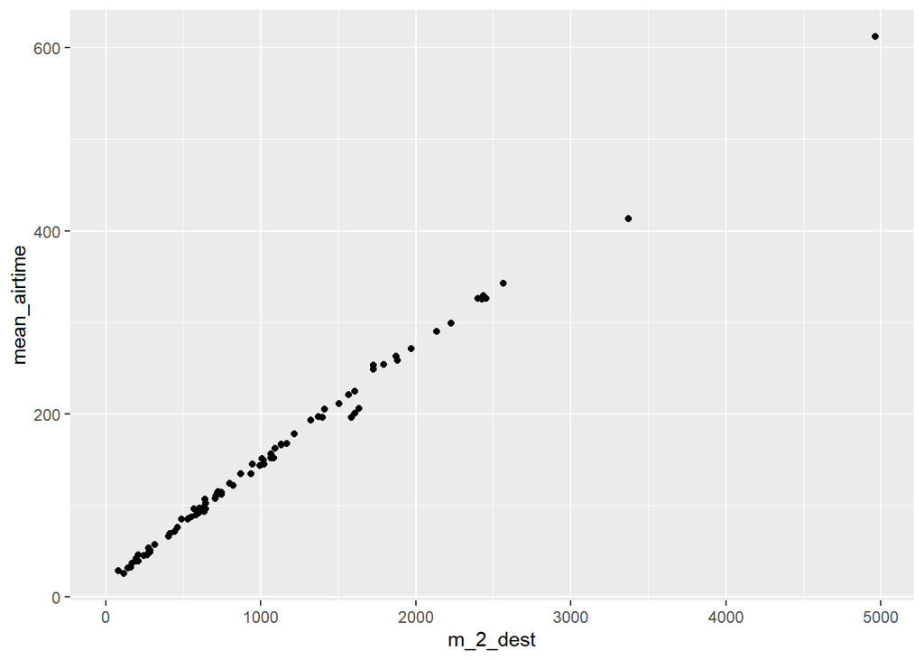

```r
# put your answer here.

dodo <- flights %>% filter(origin == "EWR") %>% group_by(dest) %>%
  summarize(mean_airtime = mean(air_time, na.rm = T), m_2_dest = mean(distance))


 dodo %>%  ggplot(aes(m_2_dest, mean_airtime)) + geom_point()
```

2b) Using this data, compute the distance divided by the average air_time. Call this the typical_speed. Plot the typical_speed on the vertical axis and distance on the horizontal axis.

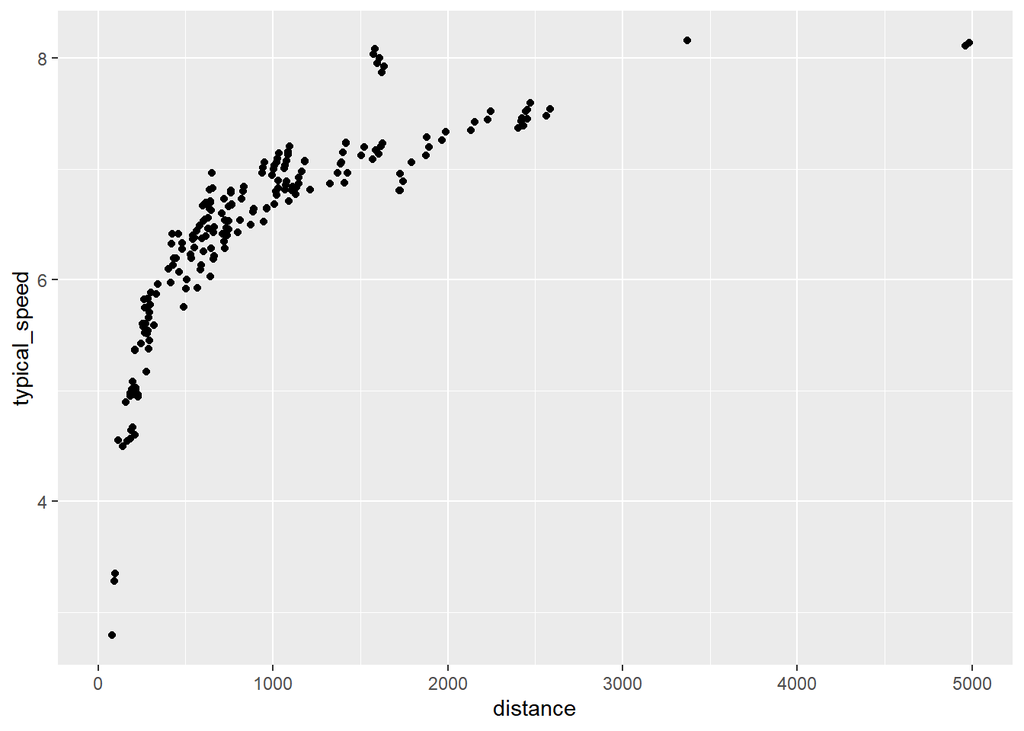

```r
# put your answer here.
dodo %>%
  left_join(flights, by = "dest") %>% mutate(typical_speed = distance/mean_airtime) %>%
   ggplot(aes(distance, typical_speed)) + geom_point()
```

#### 3. Bad weather metric

Let’s fit a linear model, for each origin x day. The outcome is the proportion of flights canceled. The features will be simple summaries of the weather.

I’ve done a bunch of work below to get you started… there is one line that you need to finish…

```r
flights_canceled =
  flights %>%
  group_by(origin, month,day) %>%
  summarise(Y = mean(is.na(dep_time)))
bad_weather =
  weather %>%
  group_by(origin, month,day) %>%
  summarize(temp = mean(temp, na.rm = T),
            dewp = mean(dewp, na.rm = T),
            humid = mean(humid, na.rm = T),
            wind_speed = mean(wind_speed, na.rm = T),
            wind_gust = mean(wind_gust, na.rm = T),
            precip = mean(precip, na.rm = T),
            visib = mean(visib, na.rm = T))
 X = flights_canceled %>% left_join(bad_weather, by = "month", "day")



# put these data frames together with a column for Y and columns for all the weather variables.  DON'T OVER THINK THIS!

#X = .....

# then, uncomment these next lines to fit a linear model...
fit = lm(Y~temp + dewp+humid+wind_speed + wind_gust+precip+visib, data = X)
summary(fit)
```

```
##
## Call:
## lm(formula = Y ~ temp + dewp + humid + wind_speed + wind_gust +
##     precip + visib, data = X)
##
## Residuals:
##      Min       1Q   Median       3Q      Max
## -0.03603 -0.02234 -0.01703 -0.00201  0.63379
##
## Coefficients:
##               Estimate Std. Error t value Pr(>|t|)
## (Intercept)  5.081e-02  1.157e-02   4.394 1.12e-05 ***
## temp        -6.954e-04  2.336e-04  -2.977  0.00291 **
## dewp         5.998e-04  2.520e-04   2.380  0.01732 *
## humid       -1.379e-04  1.218e-04  -1.132  0.25763
## wind_speed   2.164e-04  7.311e-05   2.959  0.00308 **
## wind_gust   -1.558e-04  6.501e-05  -2.397  0.01655 *
## precip       4.749e-02  1.783e-02   2.663  0.00775 **
## visib       -2.807e-04  2.742e-04  -1.023  0.30608
## ---
## Signif. codes:  0 '***' 0.001 '**' 0.01 '*' 0.05 '.' 0.1 ' ' 1
##
## Residual standard error: 0.0542 on 72736 degrees of freedom
##   (26976 observations deleted due to missingness)
## Multiple R-squared:  0.003312,   Adjusted R-squared:  0.003216
## F-statistic: 34.53 on 7 and 72736 DF,  p-value: < 2.2e-16
```

#### 4. Planes with four engines

Find all of the planes with 4 engines:

```r
# put your answer here.

planes %>% filter(engines == 4)
```

```
## # A tibble: 4 x 9
##   tailnum  year type          manufacturer   model  engines seats speed engine
##   <chr>   <int> <chr>         <chr>          <chr>    <int> <int> <int> <chr>
## 1 N281AT     NA Fixed wing m~ AIRBUS INDUST~ A340-~       4   375    NA Turbo-j~
## 2 N381AA   1956 Fixed wing m~ DOUGLAS        DC-7BF       4   102   232 Recipro~
## 3 N670US   1990 Fixed wing m~ BOEING         747-4~       4   450    NA Turbo-j~
## 4 N840MQ   1974 Fixed wing m~ CANADAIR LTD   CF-5D        4     2    NA Turbo-j~
```